# Graphics the ggplot2 Way

April 2, 2015

## Contents

- Plotting Data in R
- Introduction to ggplot2
- Deconstructing a ggplot2 Plot
- Using ggplot2
- Advanced Features and Tweaks
- Wrapup

## Plotting Data in R

## Some Options

- Base graphics
- Grid
- Lattice
- ggplot2
- And [about 40 other packages](http://cran.r-project.org/web/views/Graphics.html)

```r
df <- data.frame(x=1:10, y=rnorm(10))
head(df)
```

```
##   x           y
## 1 1  0.81224805
## 2 2 -0.07181443
## 3 3 -0.52879005
## 4 4  0.08312136
## 5 5  1.33474519
## 6 6 -1.34814258
```

## Base Graphics

Makes easy things easy, and hard things impossible.

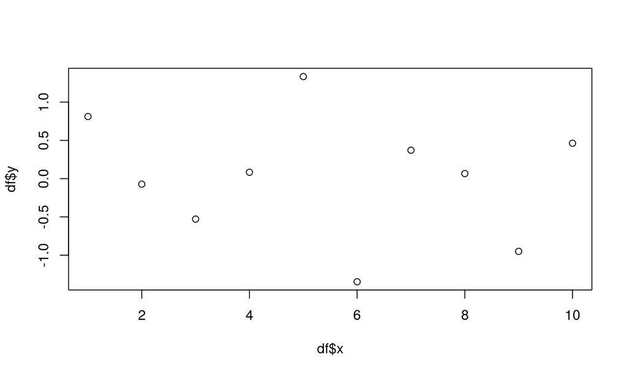

```r
plot(df$x, df$y)
```

## Grid

"Assembly language" for graphics.

## Lattice

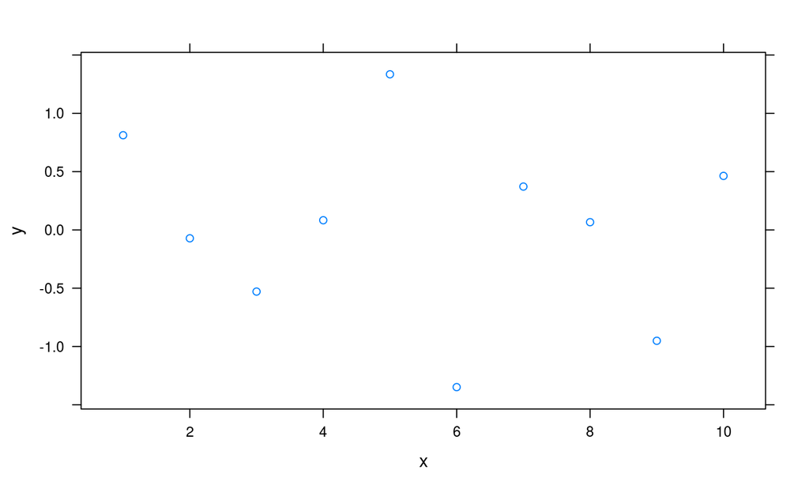

```r
library(lattice)
xyplot(y~x, df)
```

## ggplot2

Powerful and flexible; a darling of the R community.

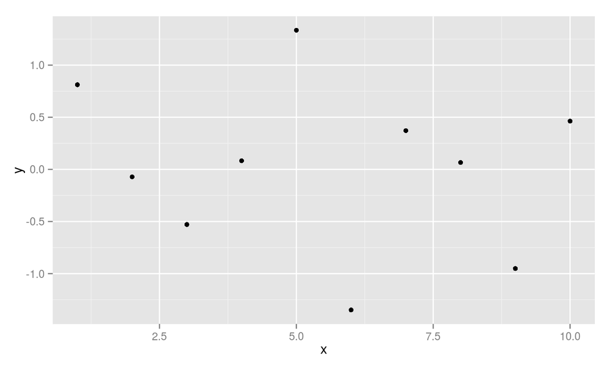

```r
library(ggplot2)

ggplot(df, aes(x, y)) + geom_point()
```

## Introduction to ggplot2

## Ways of Plotting

- `qplot()` — Shorthand
- Layer syntax — Extremely rare "in the wild".
- geom/stat syntax — Most popular method.
- autoplot — Methods (as in OO) for plotting objects.

## General Procedure

- Put your data into a dataframe.
- Declare which dataframe ggplot should use and set aesthetics.
- Add layers via geom/stat functions.
- Set options, faceting, labels, titles, …

## ?????

Geoms? Aesthetics? Facets?

## Deconstructing a ggplot2 Plot

## 4 Components

1. Geoms — physical components (point, line, path, polygon)
2. Aesthetics — visual cues (size, rotation, thickness, gradient, shape, color)
3. Coordinates
4. Faceting — copolotting (more on this later)

## Customization Nearly Unlimited

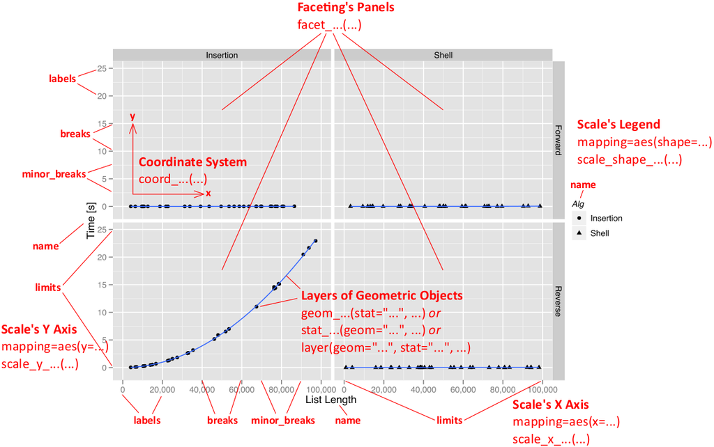

## Geom/Stat Functions

geom_abline geom_aesthetics geom_area geom_bar geom_bin2d geom_blank geom_boxplot geom_contour geom_crossbar geom_density geom_density2d geom_dotplot geom_errorbar geom_errorbarh geom_freqpoly geom_hex geom_histogram geom_hline geom_jitter geom_line geom_linerange geom_map geom_path geom_point geom_pointrange geom_polygon geom_quantile geom_raster geom_rect geom_ribbon geom_rug geom_segment geom_smooth geom_step geom_text geom_tile geom_violin geom_vline

stat_abline stat_aesthetics stat_bin stat_bin2d stat_bindot stat_binhex stat_boxplot stat_contour stat_density stat_density2d stat_ecdf stat_ellipse stat_function stat_hline stat_identity stat_qq stat_quantile stat_smooth stat_spoke stat_sum stat_summary stat_summary2d stat_summary_hex stat_unique stat_vline stat_ydensity

For explanations and examples other than those provided here, see the ggplot2 reference manual http://had.co.nz/ggplot2/

## Layering

Adding layers is not necessarily commutative!

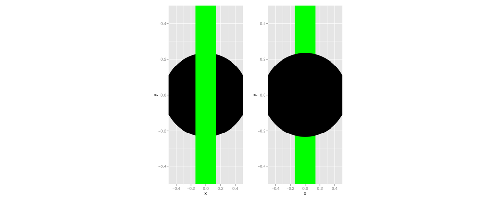

```r
g + geom_point() + geom_line()

g + geom_line() + geom_point()
```

## Using ggplot2

## The Diamonds Dataset

```r
library(ggplot2)

data(diamonds)
head(diamonds)
```

```
##   carat       cut color clarity depth table price    x    y    z
## 1  0.23     Ideal     E     SI2  61.5    55   326 3.95 3.98 2.43
## 2  0.21   Premium     E     SI1  59.8    61   326 3.89 3.84 2.31
## 3  0.23      Good     E     VS1  56.9    65   327 4.05 4.07 2.31
## 4  0.29   Premium     I     VS2  62.4    58   334 4.20 4.23 2.63
## 5  0.31      Good     J     SI2  63.3    58   335 4.34 4.35 2.75
## 6  0.24 Very Good     J    VVS2  62.8    57   336 3.94 3.96 2.48
```

```r
nrow(diamonds)
```

```
## [1] 53940
```

```r
summary(diamonds)
```

```
##      carat               cut        color        clarity
##  Min.   :0.2000   Fair     : 1610   D: 6775   SI1    :13065
##  1st Qu.:0.4000   Good     : 4906   E: 9797   VS2    :12258
##  Median :0.7000   Very Good:12082   F: 9542   SI2    : 9194
##  Mean   :0.7979   Premium  :13791   G:11292   VS1    : 8171
##  3rd Qu.:1.0400   Ideal    :21551   H: 8304   VVS2   : 5066
##  Max.   :5.0100                     I: 5422   VVS1   : 3655
##                                     J: 2808   (Other): 2531
##      depth           table           price             x
##  Min.   :43.00   Min.   :43.00   Min.   :  326   Min.   : 0.000
##  1st Qu.:61.00   1st Qu.:56.00   1st Qu.:  950   1st Qu.: 4.710
##  Median :61.80   Median :57.00   Median : 2401   Median : 5.700
##  Mean   :61.75   Mean   :57.46   Mean   : 3933   Mean   : 5.731
##  3rd Qu.:62.50   3rd Qu.:59.00   3rd Qu.: 5324   3rd Qu.: 6.540
##  Max.   :79.00   Max.   :95.00   Max.   :18823   Max.   :10.740
##
##        y                z
##  Min.   : 0.000   Min.   : 0.000
##  1st Qu.: 4.720   1st Qu.: 2.910
##  Median : 5.710   Median : 3.530
##  Mean   : 5.735   Mean   : 3.539
##  3rd Qu.: 6.540   3rd Qu.: 4.040
##  Max.   :58.900   Max.   :31.800
##
```

## Barplot

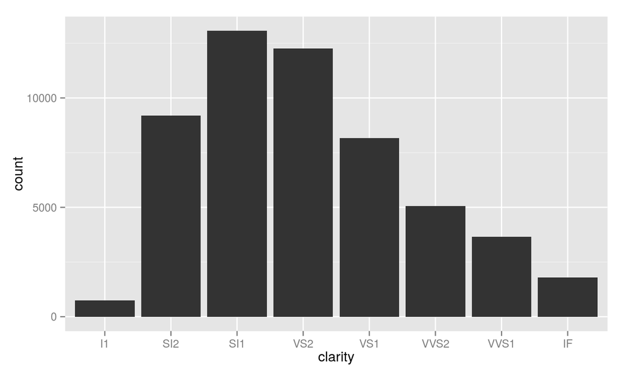

```r
ggplot(data=diamonds, aes(x=clarity) ) + geom_bar()
```

## Barplot

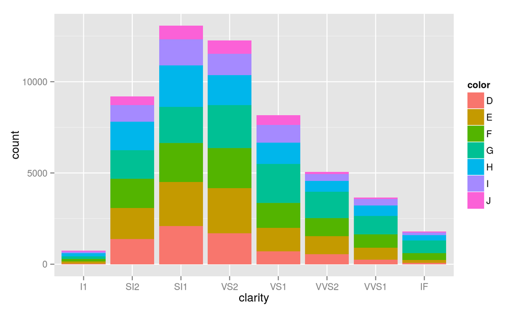

```r
ggplot(data=diamonds, aes(x=clarity, fill=color) ) + geom_bar()
```

## Pie Chart

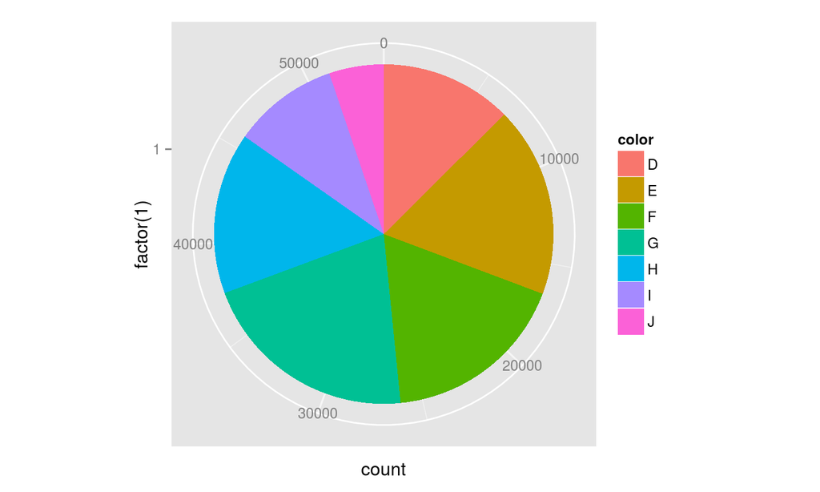

```r
ggplot(data=diamonds, aes(x=factor(1), fill=color) ) +
  geom_bar(width=1) +
  coord_polar(theta="y")
```

## Histogram

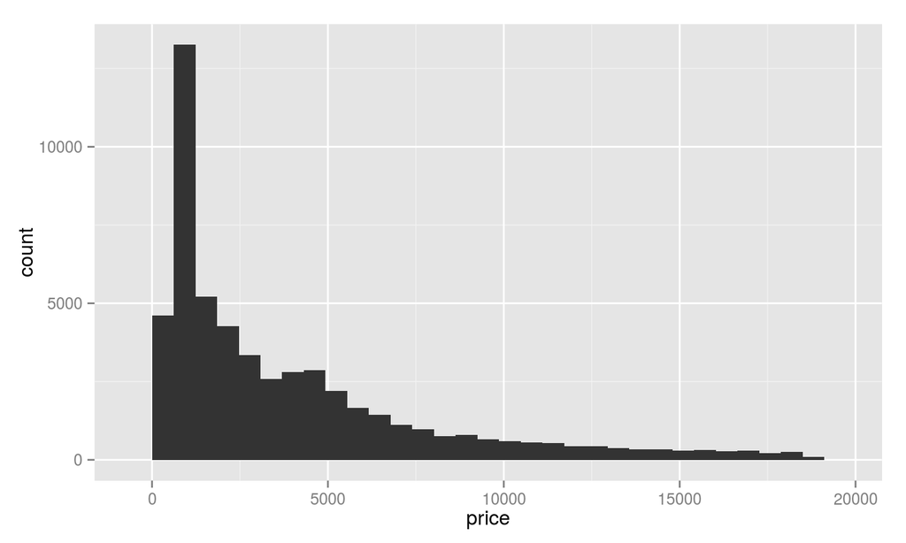

```r
ggplot(data=diamonds, aes(x=price) ) + geom_histogram()
```

## Scatterplots

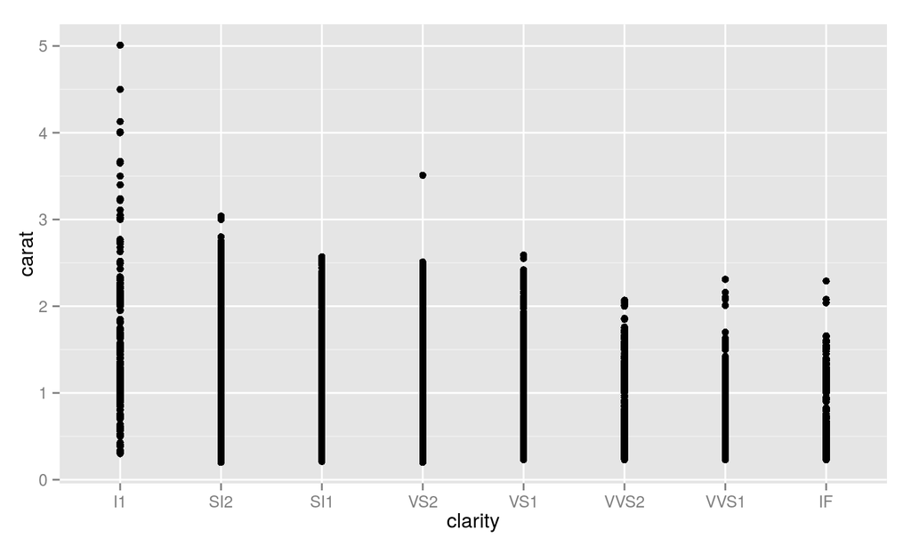

```r
g <- ggplot(data=diamonds, aes(x=clarity, y=carat) )
g + geom_point()
```

## Scatterplot with jitter

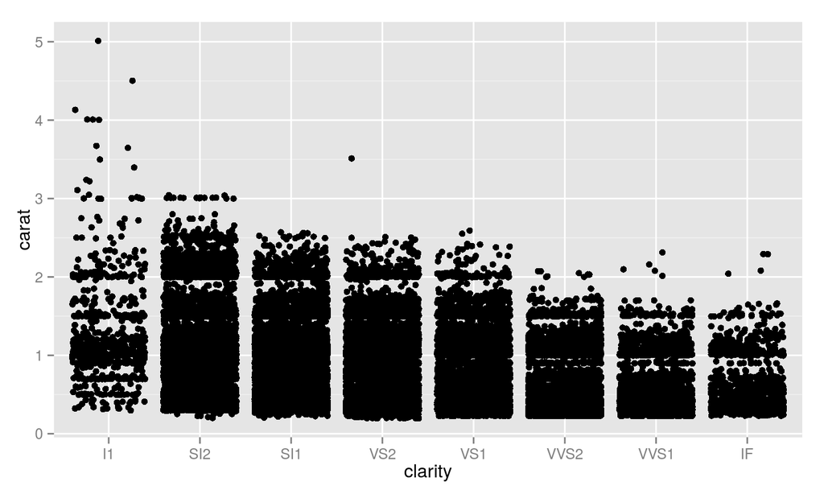

```r
g + geom_jitter()
```

## Boxplot

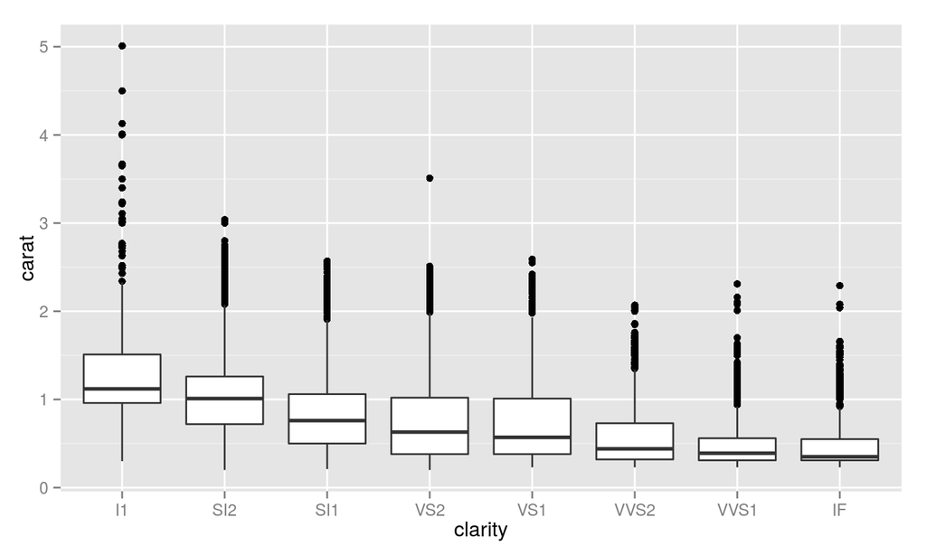

```r
g + geom_boxplot()
```

## Advanced Features and Tweaks

## Faceting

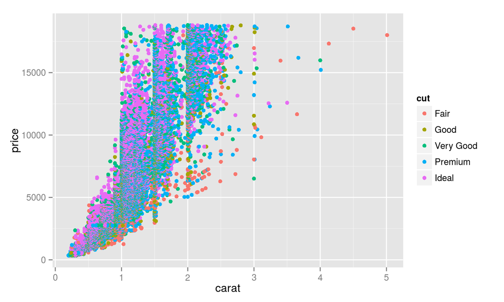

```r
g <- ggplot(data=diamonds, aes(x=carat, y=price) ) + geom_point(aes(color=cut))
g
```

## Faceting

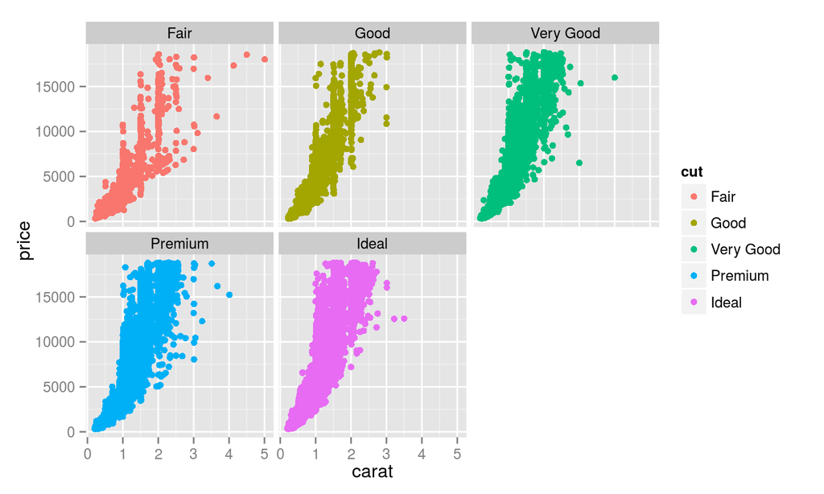

```r
g + facet_wrap(~ cut)
```

## Faceting

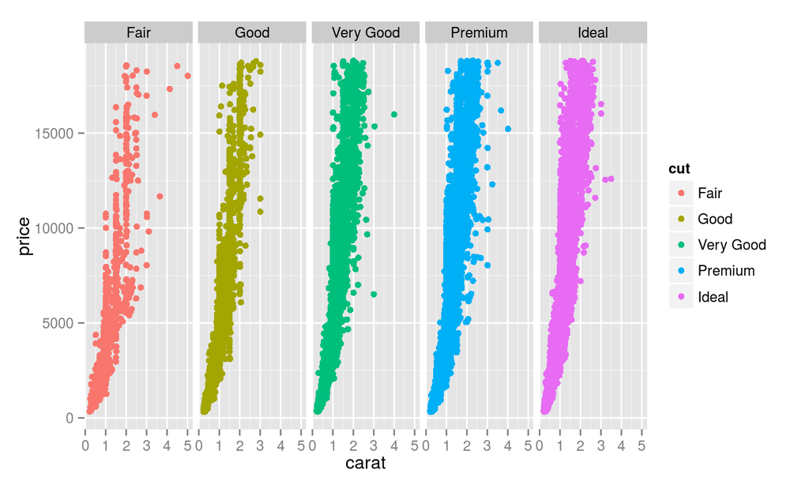

```r
g + facet_grid(~ cut)
```

## Options

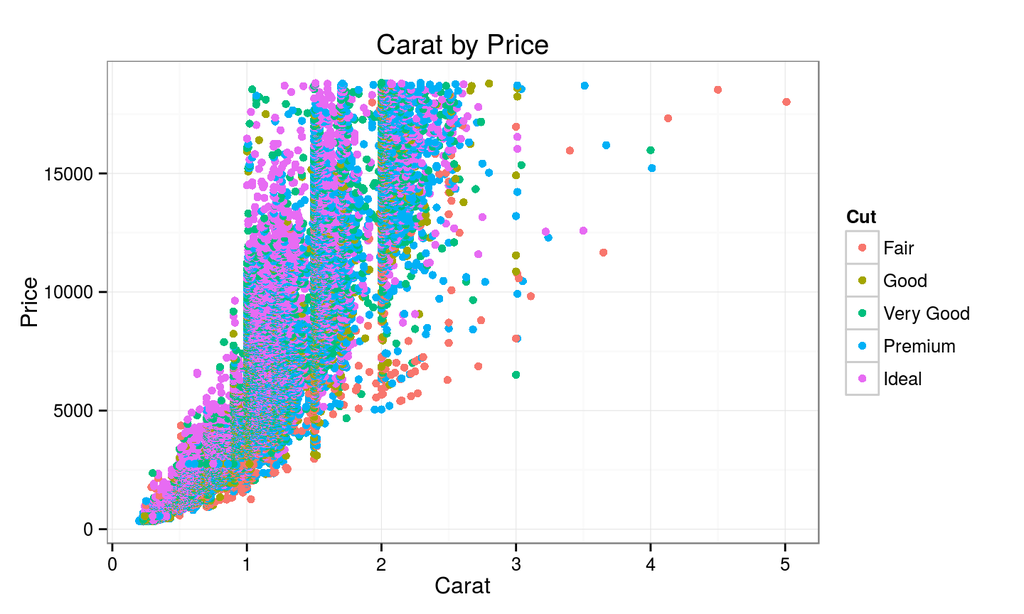

```r
g + xlab("Carat") + ylab("Price") + ggtitle("Carat by Price") +
  labs(color="Cut") + theme_bw()
```

## Saving Plots

```r
pdf("path/to/outfile.pdf")
myplot # or last_plot()
dev.off()
```

```r
ggsave("path/to/outfile.pdf", myplot)
```

See also:

```r
?pdf
?ggsave
```

## Wrapup

## Where to Learn More

- Reference Manual http://had.co.nz/ggplot2/
- CRAN page http://cran.r-project.org/web/packages/ggplot2/index.html
- Google Group https://groups.google.com/group/ggplot2
- `[ggplot2]` tag on stackoverflow
- Official Book http://ggplot2.org/book/ (available in print)

## Questions?

This presentation is available at github.com/wrathematics/2015SFSURworkshop

Exercises are also available there.